# Estimação

Alexandre Nicolella

nicolella@usp.br

FEARP/USP

2026-04-27

# Estimação

## Introdução: Inferência

## Dois problemas básicos da inferência estatística:

- Os dois problemas básicos da inferência estatísticas:
  - **Estimação de parâmetros: valores populacionais**
  - **Testes de hipótese sobre os parâmetros**
- Objetivo 1: Verificar se uma proposta de estimador de uma caractarística da população é “boa”
- Objetivo 2: Estudar técnicas para encontrar “bons” estimadores

## Analisando a qualidade dos estimadores

- Achar critérios/propriedades para julgar se um estimador é bom
- Duas perguntas básicas:
  - **Quais as características que um “bom” estimador possui?**
  - **item Como decidiremos que um estimador é “melhor” que outro?**

## Analisando a qualidade dos estimadores

- Vamos introduzir duas ideias aqui, exatidão e precisão.

**Dois conceitos importantes:**

- **Exatidão**: proximidade de cada observação do valor do centro do alvo (nosso caso: parâmetro)
- **Precisão**: proximidade de cada observação em relação ao ponto médio de todas, variância.

## Analisando a qualidade dos estimadores

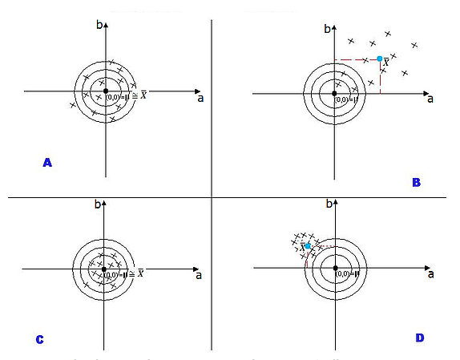

Alvo e os conceitos de Exatidão e precisão

## Analisando a qualidade dos estimadores

- O centro do alvo representa o parâmetro
- os x são as tentativas de estimar o parâmetro
- Uma boa “arma” (a estatística) é aquela que acerta ao redor do centro do alvo e menos espelhado possível. Vejamos cada um desses alvos:
- **A**: Exato (média das tentativas está no centro do alvo.) Pouco Preciso (observações muito dispersas)
- **B**: Pouco Exato e Pouco Preciso
- **C**: Exato e Preciso
- **D**: Pouco Exato e Muito Preciso
- Portanto, notamos que a melhor arma é a C.

## Estimadores e Estimação

## Estimadores

- Considere uma amostra $(X_1, ..., X_n)$ de uma v.a.
- Seja $\Theta$ um parâmetro populacional (por exemplo: $\mu$ ou $\sigma$)

**DEFINIÇÃO**

Um estimador $T$ do parâmetro $\Theta$ é qualquer função das observações da amostra, tal que:

$$T= h(X_1, ..., X_n).$$

- Portanto, um estimador é uma estatística associada a um parâmetro.

## Estimação

- Assim temos uma segunda definição:

**DEFINIÇÃO**

Uma Estimativa é o valor $t$ que somente depende da amostra observada $x_1, x_2, ..., x_n$. Ou seja, é uma função somento do banco de dados coletado:

$$t=h(x_1, x_2, . . . , x_n).$$

## Dois estimadores e suas distribuições

- Considere o retorno de uma carteira como $\Theta$.
- $T_1$ e $T_2$ dois estimadores distintos do parâmetro $\Theta$.

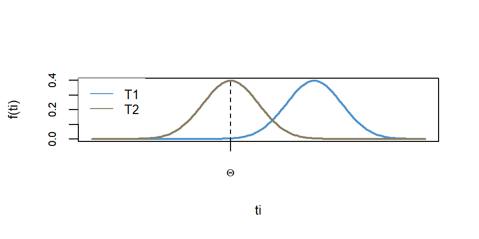

- **Questão**: Definir uma função $T_i= h(X_1, ..., X_n)$ que seja próxima de $\Theta$ segundo algum critério.

## Propriedades dos Estimadores

## Tendenciosidade ou Viés

**Comecaremos com um exemplo:**

**EXEMPLO**

- Desempenho dos alunos na Prova do ENEM, $X$, que vamos assumir que tenha distribuição normal com $\mathbb{E}(X)=2000$ e $\sigma=400$ (População)
- Observar 50 alunos que fizeram a prova em 2019
- Estimar a esperança da nota utilizando a fórmula $\bar{X}$
- Iremos repetir o processo de amostragem 100.000 vezes
- Teremos 100 mil médias
- Vamos plotar essas médias
- Vejamos a figura

## Tendenciosidade ou Viés

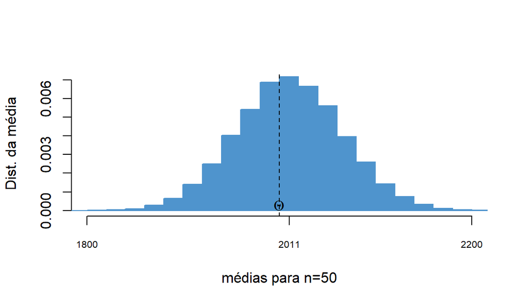

Distribuição do estimador da Esperança da Nota do ENEM

## Tendenciosidade ou Viés

- Considerando as últimas duas figuras, podemos fazer a seguinte definição:

**DEFINIÇÃO**

O estimador $T$ é chamado de estimador **não-viesado**, ou não-tendencioso, para o parâmetro $\Theta$ se:

$\mathbb{E}(T)=\Theta$ para todo $\Theta$

Independente do valor de $\Theta$, sendo a diferença $\mathbb{E}(T)-\Theta$ chamada de viés de $T$. Se a diferença é diferente de 0, T é viesado.

## Est. não viesados para Esperança e Variância pop.

- Considere uma população com N elementos e com a esperança populacional de:

$$\begin{array}{ccc}
\mu =\frac{1}{N}\sum_{j=1}^{N}X_j
\end{array}$$

- Um bom estimador poderia ser feito “copiando” a formulação populacional e considerando $n$ o tamanho da amostra:

$$\begin{array}{ccc}
\bar{X} =\frac{1}{n}\sum_{i=1}^{n}X_i
\end{array}$$

## Est. não viesados para Esperança e Variância pop.

- Observe que ele é um estimador não visesado pois

$$\begin{array}{ccc}
\mathbb{E}(\bar{X})=\frac{1}{n}\mathbb{E}[X_1+X_2+...+X_n]
\\
\\
\mathbb{E}(\bar{X})=\frac{1}{n}[\mathbb{E}(X_1)+\mathbb{E}(X_2)+...+\mathbb{E}(X_n)]
\\
\\
\mathbb{E}(\bar{X})=\frac{1}{n}[\mu+\mu+...+\mu]=\frac{1}{n}n\mu=\mu
\end{array}$$

## Est. não viesados para Esperança e Variância pop.

- Da mesma forma podemos utilizar o princípio de “copiar” para achar um estimador ($\hat{\sigma}^2$) para a variância populacional $\sigma^2$, assim:

$$\begin{array}{ccc}
\sigma^{2}=\frac{1}{N}\sum_{i=1}^{N}(X_i - \mu)^{2}
\end{array}$$

- E um possível estimador para $\sigma^{2}$ (observe que colocamos um chapéu sobre $sigma$) será:

$$\begin{array}{ccc}
\hat{\sigma}^{2}=\frac{1}{n}\sum_{i=1}^{n}(X_i - \overline{X})^{2}
\end{array}$$

## Est. não viesados para Esperança e Variância pop.

- Entretanto, tal estimador é viesado pois (ver notas de aula):

$$\begin{array}{ccc}
E(\hat{\sigma}^{2})&=E[\frac{1}{n}\{ \sum_{i=1}^{n}(X_i - \mu)^{2} - n (\overline{X} - \mu)^{2} \}]
\\
\\
&=\frac{1}{n}\{ \sum_{i=1}^{n}E (X_i - \mu)^{2} - n E (\overline{X} - \mu)^{2} \}
\\
\\
&=\frac{1}{n}\{ \sum_{i=1}^{n}Var(X_i) - n Var(\overline{X}) \}
\end{array}$$

- Como $Var(X_i)=\sigma^{2}$ e $Var(\overline{X})=\sigma^{2}/n$:

  $$\begin{array}{ccc}
  \mathbb{E}(\hat{\sigma}^{2})=\frac{1}{n}\{ \sum_{i=1}^{n} \sigma^{2} - n \frac{ \sigma^{2}}{n} \}
  \\
  \\
  = \sigma^{2} - \frac{ \sigma^{2}}{n} =\sigma^{2}\frac{n-1}{n}
  \end{array}$$

## Est. não viesados para Esperança e Variância pop.

- Assim $\hat{\sigma^{2}}$ é um estimador viesado para o parâmetro $\sigma^{2}$ e o viés é dado por:

$$\begin{array}{ccc}
V = V(\hat{\sigma^{2}})= E(\hat{\sigma^{2}})-E(\sigma)=-\frac{\sigma^{2}}{n}
\end{array}$$

- Como $V$ é negativo estamos subestimando o verdadeiro valor do parâmetro. Entretanto, o viés diminui com n:
- Quando $n \rightarrow \infty$ temos que $V \rightarrow 0$

## Est. não viesados para Esperança e Variância pop.

- Para obter o melhor estimador não-viesado do parâmetro $\sigma^2$ basta considerar

$$\begin{array}{ccc}
S^2= \frac{n}{n-1} \hat{\sigma}^2
\\
\\
\therefore \mathbb{E}(\frac{n}{n-1} \hat{\sigma}^2)=\frac{n}{n-1} \mathbb{E}(\hat{\sigma}^2)=\frac{n}{n-1}\frac{n-1}{n} \sigma^2=\sigma^2
\end{array}$$

- Definimos:
  $$\begin{array}{ccc}
  S^2= \frac{n}{n-1} \hat{\sigma}^2 = \frac{n}{n-1}\frac{1}{n} \sum_{i=1}^{n}(X_i - \overline{X})^2=\frac{1}{n-1}\sum_{i=1}^{n}(X_i - \overline{X})^2
  \end{array}$$
- Onde:

$$\begin{array}{ccc}
E(S^2)=\sigma^2
\end{array}$$

- $S^2$ é um estimador não-viesado

## Eficiência

- Agora temos a seguinte situação, dado dois estimadores não viesados, como escolher qual dos dois seria melhor?
- Dois estimadores para a esperança, média e mediana! Vejamos gráfico

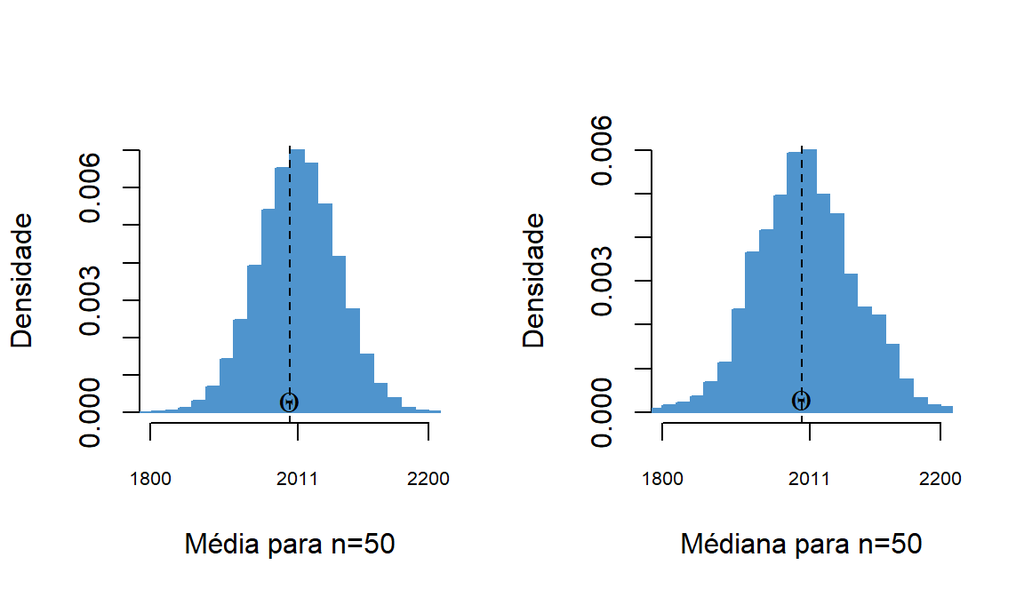

Distribuição de dois estimadores não viesádos para a Esperança da População , média e mediana

## Eficiência

- A precisão do estimador que utiliza a media amostral é maior do que a do estimador que utiliza a mediana amostral. Matematicamente temos o seguinte:

- $\bar{X}$ tem menor variância e é melhor a partir deste critério.
- Em termos práticos, estimadores mais precisos ou eficientes, geram estimativas que tem maior chance de estarem perto do verdadeiro parâmetro.

## Eficiência

- **Definindo**:

**DEFINIÇÃO**

Sejam $T_1$ e $T_2$ são dois estimadores não-viesados de um mesmo parâmetro $\Theta$. Dizemos que $T_1$ é mais eficiente do que o estimador $T_2$ se

$$Var(T_1) < Var(T_2)$$

- Entre estimadores não viesados optamos sempre pelo de menor variância.

## Erro quadrático médio

- A performance de um estimador deve ser avaliada principalmente pela maneira que se dispersa ao redor do parâmetro $\Theta$ a ser estimado.
- Considere o erro amostral:

$$e=T-\Theta$$

- Esse é o erro que cometemos ao estimar o parâmetro $\Theta$ da distribuição da v.a. $X$ pelo estimador $T$ baseado em uma amostra

## Erro quadrático médio

- Assim podemos definir:

**DEFINIÇÃO**

Sendo $T$ o estimador do parâmetro populacional $\Theta$, então o Erro Quadrático Médio (EQM) do estimador $T$ será:

$$\begin{array}{ccc}
EQM(T;\Theta) = E(e^{2})= E(T-\Theta)^{2}
\end{array}$$

**Desenvolvendo:**

$$\begin{aligned}
\operatorname{EQM}(T;\Theta) &= E(e^{2}) = E\left[(T-\Theta)^{2}\right] \\
&= E\left[(T-E(T))^{2}\right] + \left[E(T)-\Theta\right]^{2} \\
&= \operatorname{Var}(T) + V^{2}
\end{aligned}$$

- Sendo $Var (T)$ a variância do estimador e $V^{2}$ o viés ao quadrado.
- O estimador com menor EQM, será aquele que reduz viés e variância.

## Erro quadrático médio

- O gráfico apresenta o EQM da média e da mediana ao estimar a esperança da nota do ENEM.

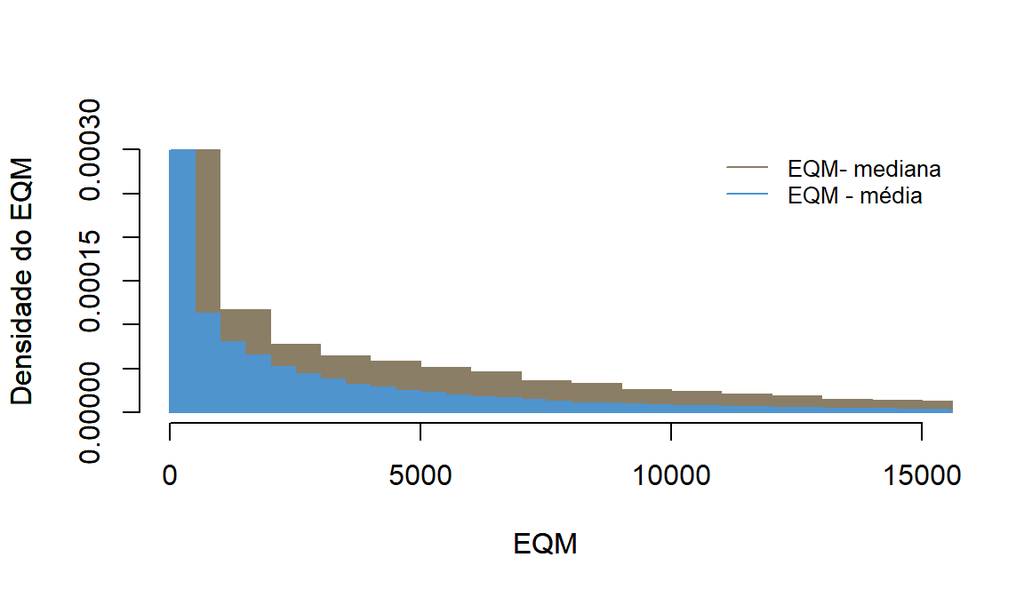

Erro Quadrático Médio de dois estimadores não viesádos para a Esperança da População , média e mediana

## Consistência

- A consistência é uma propriedade que surge quando o tamanho amostral cresce, ou seja, quando $n\rightarrow \infty$.
- Propriedade importante, poisum estimador deve convergir para o verdadeiro parâmetro quando n aumenta

**EXEMPLO**

- Podemos calcular $\overline{X}$ para diversos tamanho de amostra, obtemos uma sequência de estimadores $\overline{X}_n$ para n=1,2,….
- Quando $n$ cresce e a distribuição de $\overline{X}_n$ torna-se mais concentrada ao redor da média real $\mu$.
- Dessa forma, $\overline{X}_n$ é uma sequência consistende de estimadores de $\mu$.
- Veja o gráfico abaixo para amostra de tamanho 50, 500 e 1500.

## Consistência

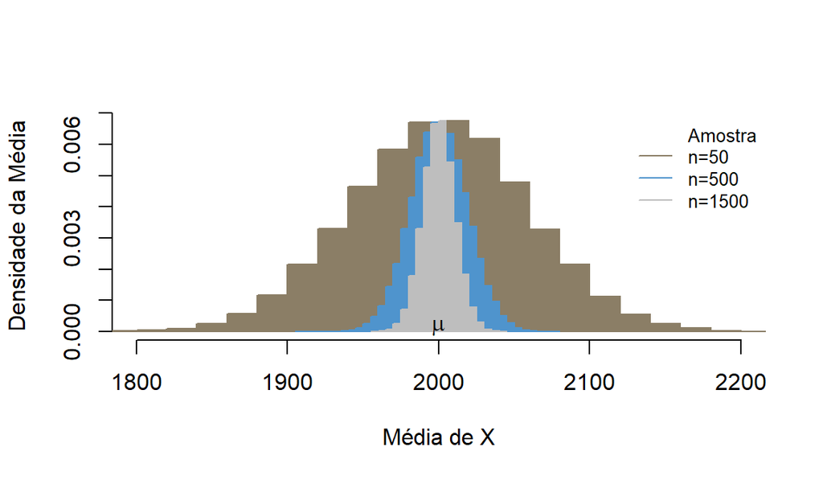

Consistência do estimador não viesados para a Esperança da População , média

- Observe que ao aumentar o tamanho amostral a distribuição vai se concentrando ao redor do parâmetro populacional.

## Consistência

- Assim podemos definir:

**DEFINIÇÃO**

Uma sequência $\{T_n \}$ de estimadores de um parâmetro $\Theta$ é consistente se para todo

$\varepsilon >0$:

$$\begin{array}{ccc}
P\{ | T_n - \Theta | > \varepsilon \} \rightarrow 0 , n \rightarrow \infty
\end{array}$$

Para o caso específico da média $\bar{X}$, tem-se:

$$\begin{array}{ccc}
P\{ | \bar{X} - \mu | > \varepsilon \} \rightarrow 0 , n \rightarrow \infty
\end{array}$$

## Consistência

- Dessa forma temos o seguinte Teorema:

**TEOREMA**

- Considerando a desigualdade de Tchebycheff, tem-se:

$$\begin{array}{ccc}
P\{ | T_n - \Theta | < \varepsilon \} \geq 1-\frac{\sigma^2}{\varepsilon^2n}
\end{array}$$

- Dessa forma,uma sequência $\{T_n \}$ de estimadores de um parâmetro $\Theta$ é consistente se:

$$\begin{array}{ccc}
lim_{n \rightarrow \infty} P\{ | T_n - \Theta | < \varepsilon \} = 1
\end{array}$$

Podemos ainda escrever:

plim$T_n=\Theta$

$T_n\overset{p}{\to}\Theta$}

## Consistência

- Uma maneira mais direta para testar a consistência do estimador pode-se utilizar o seguinte resultado:

**Proposição**:  
- Uma sequência $\{T_n \}$ de estimadores de um parâmetro $\Theta$ é consistente se:

$$\begin{array}{ccc}
lim_{n \rightarrow \infty} E(T_n) = \Theta
\end{array}$$

$$\begin{array}{ccc}
lim_{n \rightarrow \infty} Var (T_n) = 0
\end{array}$$

## Consistência

**EXEMPLO**

Seja $S^{2}$ um estimador não viesado, sendo, $E(S^{2})=\sigma^{2}$. Se X tiver uma distribuição Normal ~$N(\mu,\sigma^{2})$ e $X_1, ..., X_n$ as $n$ medições de $X$, então:

$$\begin{array}{ccc}
Var(S^{2})=\frac{2 \sigma^{4}}{n-1}
\end{array}$$
e
$$\begin{array}{ccc}
lim_{n \rightarrow \infty}Var(S^{2})=0
\end{array}$$

## Consistência

**EXEMPLO**

$$\begin{array}{ccc}
\mathbb{E}(\hat{\sigma^{2}})=\hat{\sigma^{2}}- \frac{\hat{\sigma^{2}}}{n} \Rightarrow lim_{n \rightarrow \infty} \mathbb{E}(\hat{\sigma^{2}})={\sigma^{2}}
\end{array}$$

$$\begin{array}{ccc}
Var(\hat{\sigma^{2}})= (\frac{n-1}{n})^{2}. Var(S^{2}) = \frac{(n-1)^2}{n^{2}} \frac{2\sigma^{4}}{n-1}=\frac{n-1}{n^{2}} 2 \sigma^{4}
\\
\\
\Rightarrow lim_{n \rightarrow \infty} Var(\hat{\sigma^{2}})=0
\end{array}$$

Portanto, $\hat{\sigma^{2}}$ é um estimador **consistente**

# Estimação

## Métodos de Estimação e o Modelo Populacional

## Introdução

- Até agora “imitamos” a fórmula de calculo da população para encontrar estimadores
- Vamos considerar que gostariamos de compreender os determinantes da renda de uma pessoa.
- Uma dos principais determinantes é o nível educacional
- Dessa forma podemos representar a relação da seguinte forma

$$Renda=h(Educação)$$

- Vejamos um exemplo

## Introdução

- Vejamos o gráfico de diversos países anos de estudos vs. ln da renda per capita

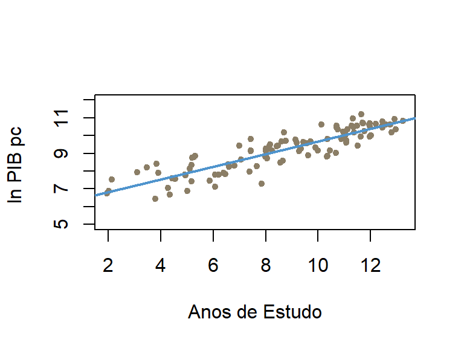

Anos de estudos e ln do PIB pc de diversos países em 2010

## Introdução

- Observe uma relação ascendente, quanto maior a educação maior a renda
- Entretanto ela não é precisa.
- Existe um componente aleatório que não nos permite determinar precisamente a renda dada a escolaridade
- Podemos entender o problema da seguinte forma

$$Renda = h(Educação) + flutuação Aleatória$$

- Qual o deveria ser o h?

## O Modelo Populacional

- O que podemos assumir é que h uma função linear como representada pela linha azul no gráfico.
- Podemos dizer que existe uma correlação entre renda e educação, ou seja, uma dependência linear.
- Um possível e mais comum modelo seria uma função linear que relaciona renda e educação e que considere as flutuações, ou seja:

$$Renda=\alpha+\beta . Educação + u_i$$

## O Modelo Populacional

$$Renda=\alpha+\beta . Educação + u_i$$

- Essa é a linha de regressão sendo que $\alpha$ e $\beta$ parâmetros populacionais.
- O $\beta$ representa a influência de um ano a mais de educação sobre a renda per capita
- A $\mathbb{E}(u_i)=0$ para $i=1,...n$
- Agora que temos uma relação de como educação e renda se relacionam na população precisamos achar um estimador para $\beta$, ou seja, $\hat{\beta}=g(Y_i,X_j)$
- Nossa nova questão agora é achar quem é $g$

## Estimadores do Modelo Populacional

Existem algumas maneiras para acharmmos g:

- Estimadores de Momentos
- Estimadores de Máxima Verossimilhança
- Mínimos Quadrados

Veremos duas delas Minimos Quadrados e Máxmia Verossimilhança.

## Estimadores de Mínimos Quadrados

## Introdução

- Considere o gráfico

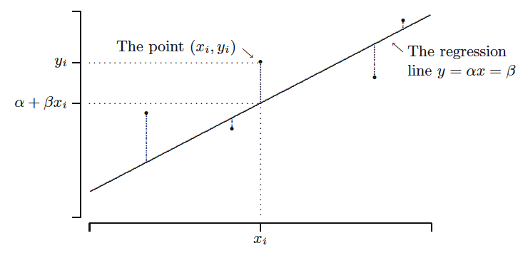

Valores observados e estimados para y

## Introdução

- Pontos representam valores do par ordenado $(x_i,y_i)$.
- A linha representa os valores estimados ou projetados de $Y$ para dado valor de $X$, ou seja, $\hat{y}_i=\alpha+\beta.x_i$.
- Um bom estimador, ou seja, um bom $\hat{\alpha}$ e $\hat{\beta}$, deveria ser aquele que minimize a distância entre observado $y_i$ e estimado$\hat{y_i}$.
- Assim, minimizamos o erro que cometemos ao tentar estimar o valor observado.
- Os erros podem ser assim descritos:

$$e=(y_i-\hat{y}_i)=(y_i-\alpha-\beta.x_i)$$

- Como não é importante se os erros são positivos ou negativos, utilizamos aqui a minimização da soma dos erros ao quadrado.

## O Princípio de Minimos Quadrados

- Portanto, minimizamos:

$$S(\alpha, \beta)=\sum_{i=1}^{n}(y_i-\hat{y}_i)^2=\sum_{i=1}^{n}(y_i-\alpha-\beta.x_i)^2$$

- Podemos entender essa minimização como o procedimento para encontrar os estimadores $\hat{\alpha}$ e $\hat{\beta}$ que gerem o menor erro quadrático médio.
- Encontraremos os estimadores lineares que reduzem viés e variância.

## Estimadores de Minimos Quadrados

Minimizando os erros ao quadrado em relação a $\alpha$ e utilizando a regra da cadeia (considere $z=y_i-\alpha-\beta.x_i)$:

$$\begin{array}{clc}
S(\alpha, \beta)=&\sum_{i=1}^{n}(y_i-\alpha-\beta.x_i)^2
\\
\\
\frac{\partial S(\alpha, \beta)}{\partial \alpha} =& 2\sum (y_i -\hat{\alpha}- \hat{\beta} x_i)(-1)=0
\\
\\
0=& -\sum y_i+n\hat{\alpha}+\hat{\beta}\sum x_i
\\
\\
\hat{\alpha}=&\frac{\sum y_i-\hat{\beta}\sum x_i}{n}
\\
\\
\hat{\alpha}=&\bar{y}-\hat{\beta}\bar{x}
\end{array}$$

## Estimadores de Minimos Quadrados

Agora derivando em relação a $\beta$:

$$\begin{array}{rlc}
\frac{\partial S(\alpha, \beta)}{\partial \beta} =& 2\sum (y_i -\hat{\alpha}- \hat{\beta} x_i)(-x_i)=0
\\
\\
0=& -2\sum y_i x_i + 2\sum (x_i \bar{y}-x_i\hat{\beta}\bar{x})+2\hat{\beta}\sum x_i^2
\\
\\
0=& -2\sum y_i x_i + 2\bar{y}\sum x_i -2\hat{\beta}\bar{x}\sum x_i+2\hat{\beta}\sum x_i^2
\\
\\
2\hat{\beta}(\sum x_i^2-\frac{\sum x_i}{n}\sum x_i) =& 2(\sum y_i x_i - \frac{\sum y_i}{n}\sum x_i)
\end{array}$$

$$\begin{array}{rlc}
\hat{\beta}(\frac{n\sum x_i^2-(\sum x_i)^2}{n}) =& \frac{n\sum y_i x_i - \sum y_i\sum x_i}{n}
\\
\\
\hat{\beta}=&\frac{n\sum y_i x_i - \sum y_i\sum x_i} {n\sum x_i^2-(\sum x_i)^2}
\end{array}$$

## Estimadores de Minimos Quadrados

- Os estimadores de mínimos quadrados são:
  $$\begin{array}{rlc}
  \hat{\beta}=&\frac{n\sum y_i x_i - \sum y_i\sum x_i} {n\sum x_i^2-(\sum x_i)^2}= \frac{\sum (x_i - \bar{x})(\sum y_i-\bar{y})}{\sum (x_i-\bar{x})^2}=
  \frac{\sum y_i x_i - n\bar{y}\bar{x}} {\sum x_i^2-n\bar{x}^2}
  \\
  \\
  \hat{\alpha}=&\bar{y}-\hat{\beta}\bar{x}
  \end{array}$$

## Estimadores de Minimos Quadrados

- Para o modelo sem intercepto (muito pouco utilizado em econometria), tem-se:

$$\begin{array}{rlc}
S( \beta)=&\sum_{i=1}^{n}(y_i-\beta.x_i)^2
\\
\\
\frac{\partial S( \beta)}{\partial \beta} =& 2\sum (y_i - \hat{\beta} x_i)(-x_i)=0
\\
\\
0 =& 2(-\sum x_iy_i + \sum \hat{\beta} x_i^2)
\\
\\
\hat{\beta} \sum x_i^2 =& \sum x_iy_i
\\
\\
\hat{\beta}_{MQ}=&\frac{\sum x_iy_i}{\sum x_i^2 }
\end{array}$$

## Estimativas de Minimos Quadrados

- Vamos utilizar os nossos dados apresentados acima e calcular no R o resultado

```
[1] 0.3568401
```

```
[1] 6.092204
```

```
Call:
lm(formula = ln_salario ~ educa)

Coefficients:
(Intercept)        educa
     6.0922       0.3568
```

## Interpretanto as Coeficientes

- Cada ano a mais de educação que um país aumenta em 0.357 o ln da renda per capita.
- Nossa equação para achar $\hat{Y}$ será:

$$\hat{Y}=\hat{\alpha}+\hat{\beta}.x$$

ou seja,

$$\hat{Y}=6.092+0.357.x$$

- Dessa forma um país que consiga atingir 10 anos de média de educação terá o ln da renda estimado em $9.66$.

## Interpretanto as Coeficientes

- Existem maneiras de ler as estimativas obtidas. Verão isso em econometria com mais detalhes
- Aqui somente deixamos a interpretação desse coeficiente e não entramos no detalhe da sua explicação.
- Como é um modelo com $Y$ em ln e $x$ em nível, modelo log-linear, deveremos fazer $exp(0.35)=1,43$, isso implica que cada aumento de 1 ano de escolaridade média da população aumenta da renda do país em 43%.
- Importante que cada modelo, log-log, log-linear e linear-linear tem sua própria maneira de interpretar o coeficiente.

## Estimador de Máxima Verossimilhança

## Intuição

- Gostaríamos de saber qual seria uma boa estimativa da esperança da nota do IDEB nos município brasileiros para os primeiros anos do fundamental em 2017.
- Vamos coletar 500 municipios e vamos plotar o histograma conforme figura 3 que segue.

## Intuição

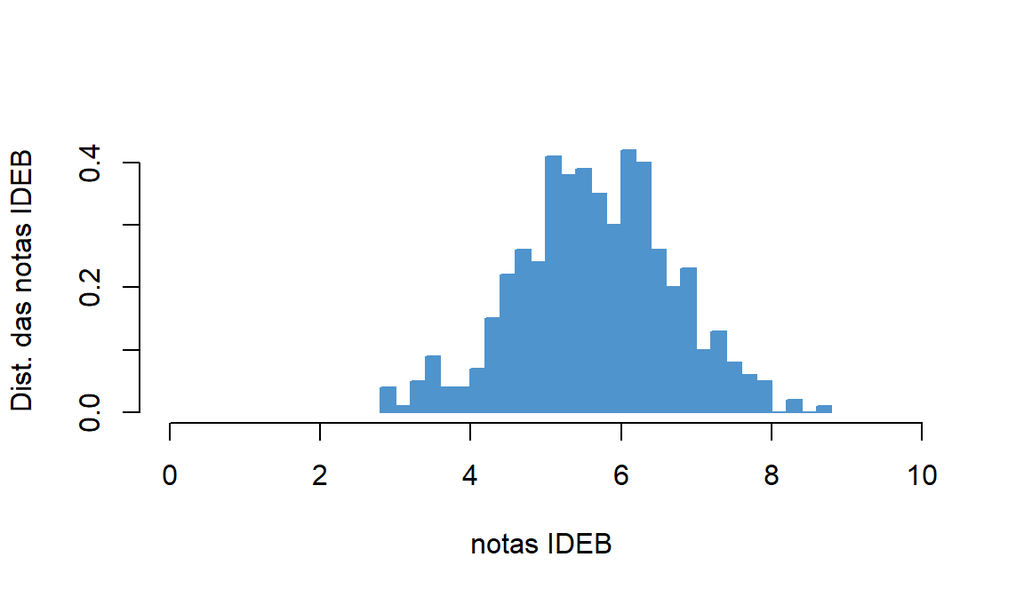

Distribuição da amostra das notas do IDEB 2017, para os primeiros anos do fundamental de 500 municípios

## Intuição

- Temos uma amostra de 500 elementos onde $X_1, X_2,...,X_{500}$ são as 500 medições sendo que todas elas tem a mesma distribuição e igual a de $X$, $f(x;\mu)$.
- O gráfico acima apresenta os valores observados das medições, $x_1,x_2,...,x_{500}$.
- Dessa forma temos os valores observados mas não temos ideia de qual distribuição populacional esses dados vieram, ou seja, de qual $f(x;\mu)$ esses dados foram extraídos?
- Supondo que a distribuição populacional é uma normal e que temos os dados acima já observados, a questão é achar qual a fdp de $X$ entre todas as possíveis (alterando o valor do parâmetro) é a mais provável de ter gerado os dados que observamos?
- Vejamos a simulação abaixo, figura 4, que considera os dados coletados e diversas distribuições normais para diferentes valores do parâmetro $\mu$.

## Intuição

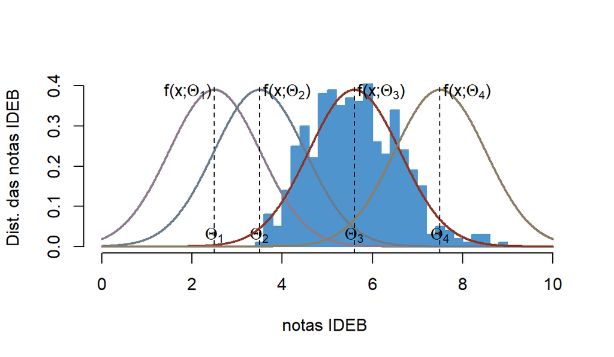

Distribuição da amostra das notas do IDEB 2017, e diversas possibilidades fdp do ideb populacional

## Intuição

- Em azul, o histograma das observações coletadas (amostra de 500 municípios).
- Foram simuladas diversas distribuições POPULACIONAIS normais todas com mesmo desvio padrão mas diversos valores para a esperança que chamamos de $\Theta$.
- A questão que temos é qual seria a distribuição que torna mais provável termos tirado essa amostra? De qual distribuição $f(x;\Theta_1)$, $f(x;\Theta_2)$, $f(x;\Theta_3)$ ou $f(x;\Theta_4)$ essa amostra pode ter vindo?
- Visualmente podemos até ter a intuição, mas precisamos de uma forma mais precisa.
- Para resolver esse problema utilizamos a função de verossimilhança que representa a verossimilhança de um parâmetro $\Theta$ condicional aos valores observados.

## A Função de Verossimilhança

- A **Função de Verossimilhança** $L$ será:
  $$\begin{array}{ccc}
  L(\Theta|X_1,...,X_n)= f(x_1|\Theta)f(x_2|\Theta)...f(x_n|\Theta)
  \end{array}$$
- A função $L(\Theta|X_1,...,X_n)$ representa a verossimilhança do parâmetro $\Theta$ dado os valores observados $x_i$.
- Vamos simular a função de verossimilhança para o problema anterior das notas do IDEB.
- Consideraremos os 500 municipios amostrados $x_i$, vamos simular valores de $\Theta$ e considerar o $\sigma=1$ por facilidade.
- Haviamos suposto que as notas do IDEB dos município era normalmente distribuída com esperança $\mu$ e variância $1$.

## A Função de Verossimilhança

- Assim,

$$\begin{array}{ccc}
f(x)=\frac{1}{\sqrt{2 \pi}} e^{-1/2 (x-\mu)^2}
\end{array}$$

- Dessa forma a Função de Verossimilhança será o produtório de normais:

$$\begin{array}{ccc}
L(\mu| x_1,...,x_n)= \frac{1}{2 \pi ^{n/2}} exp[-1/2 \sum_i^n (x_i - \mu)^2 ]
\end{array}$$

- Agora vamos simular diversos valores para os parâmetros populacionais e encontrar a função de verossimilhança, veja figura 5.

## A Função de Verossimilhança

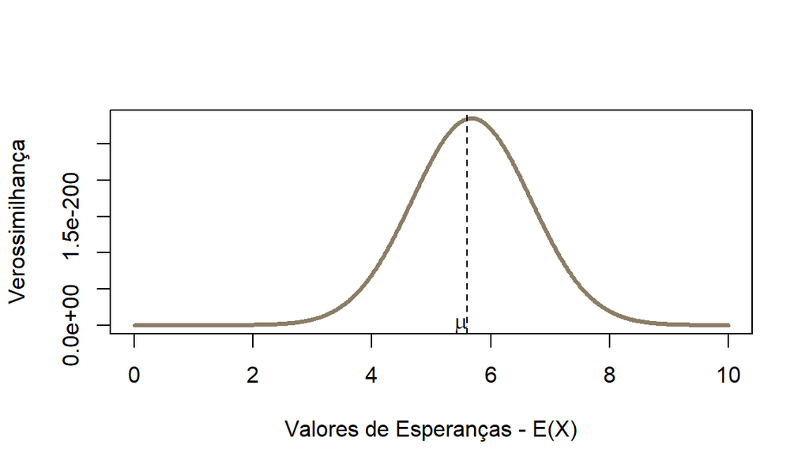

Simulação da Função de Verossimilhança

## A Intuição da Função de Verossimilhança

- O que fizemos?
- Condicional a amostra que obtivemos simulamos diversos valores de $\mathbb{E}(X)=\mu$ e calculamos a função para cada um dos 1000 valores simulados do parâmetro populacional.
- Obtivemos 1000 valores da função de verossimilhança.
- Assim, essa função nos fornece a probabilidade de encontrarmos certo valor de parâmetro condicional aos valores observados de $x_i$.
- Observe que o ponto de máximo da função de verossimilhança está localizado bem próximo do verdadeiro parâmetro populacional.
- Portanto buscamos:

$$\begin{array}{ccc}
max L(\hat{\Theta}|x_1,...,x_n)
\end{array}$$

- Esse será o estimador $\hat{\Theta}$ preferido pois aumenta a probabilidade de obter valores amostrais como $x_1,...,x_n$.

## O Estimador de Máxima Verossimilhança

1. Definindo a Função de Verossimilhança

**DEFINIÇÃO**

O estimador de Máxima de Verossimilhança, $EMV$, de $\Theta$, isso é, $\hat{\Theta}$ baseado em uma amostra aleatória $x_1,...x_n$, é aquele que torna máxima

$$L(\Theta|x_1,...,x_n)$$

$\rightarrow$ $\hat{\Theta}$ será uma estatística e portanto uma v.a.

$\rightarrow$ $\Theta$ pode ser um vetor quando possuímos mais de um parâmetro desconhecido. Por exemplo, $\Theta=(\mu,\sigma)$

## O Estimador de Máxima Verossimilhança

2. Utilizando o ln da FV
- Por facilidade computacional e para evitar cálculos mais complexos utilizamos a função log-verossimilhança.
- Essa diminui bastante as exigências computacionais
- O ln é uma função crescente, sendo que o máximo na função ln e sem ln serão os mesmos para $\Theta$.

$$\begin{array}{ccc}
l(\Theta| x_1,...,x_n) = lnL(\Theta|x_1,...,x_n,)
\end{array}$$

## O Estimador de Máxima Verossimilhança

3. Achando o ponto de máximo da Função de Verossimilhança

$$\begin{array}{ccc}
\frac{\partial l(\Theta| x_1,...,x_n)}{\partial \Theta} = 0
\end{array}$$

Se temos $\Theta=(\mu,\sigma)$ teremos equações simultâneas:

$$\begin{array}{ccc}
\frac{\partial l(\mu,\sigma|x_1,...,x_n) }{\partial \mu} = 0
\\
\\
\frac{\partial l(\mu,\sigma|x_1,...,x_n) }{\partial \sigma} = 0
\end{array}$$

## Propriedades dos Estimadores de M.V.:

1. Pode ser tendencioso mas pode ser corrigido pela multiplicação de uma constante apropriada
2. Sob condições gerais as estimativas de M.V. são consistentes, ou seja, assintoticamente não viesados e de variância mínima
3. Importante - **Propriedade de invariância**: Supoha que $\hat{\Theta}$ seja uma estimativa M.V. de $\Theta$. Pode-se mostrar que uma estimativa M.V. de $g(\Theta)$ seja $g(\hat{\Theta})$, onde $g(.)$ é uma função monótona contínua. Exemplo: $m^2=\hat{\Theta}$ ou $m=\sqrt{\hat{\Theta}}$

## Exemplos

- Vejamos dois exemplos que pode nos ajudar a fixar o conceito.
- Exemplo 1: Função Distribuição Exponencial

**EXEMPLO**

Considere a distribuição de uma variável $T$ com parâmetro $\beta$:
$$\begin{array}{ccc}
f(t)=\beta e^{-\beta t}, t \geq 0
\end{array}$$

Suponha $n$ componentes tal que:

$$\begin{array}{ccc}
L(\beta|t_1,...,t_n) = f(t_1,\beta)f(t_2,\beta)...f(t_n,\beta)
\\
\\
= \beta e^{-\beta T_1}...\beta e^{-\beta T_n}
\\
\\
= \beta^n e^{-\beta \sum T_i}
\end{array}$$

## Exemplos

- Continuação

**EXEMPLO**

Aplicando o log:
$$\begin{array}{ccc}
ln L(\beta|t_1,...,t_n) = l(\beta|t_1,...,t_n) = n .ln \beta - \beta \sum T_i
\end{array}$$
Temos o máximo:
$$\begin{array}{ccc}
\frac{\partial l(.)}{\partial \beta}=\frac{n}{\beta} -\sum T_i = 0
\\
\\
\frac{n}{\beta} = \sum T_i
\\
\\
\overline{T}=\frac{1}{\beta}
\end{array}$$

## Exemplos

- Exemplo 2: Função Distribuição Normal

**EXEMPLO**

Suponha-se que a variável aleatória $X$ seja normalmente distribuída com esperança $\mu$ e variância $1$.

$$\begin{array}{ccc}
f(x)=\frac{1}{\sqrt{2 \pi}} e^{-1/2 (x-\mu)^2}
\end{array}$$

Encontrando o estimador do parâmetro $\mu$. Se $(X_1,...,X_n)$ uma amostra aleatórida da v.a. $X$ a FMV será:

$$\begin{array}{ccc}
L(\mu|x_1,...,x_n)= \frac{1}{2 \pi ^{n/2}} exp[-1/2 \sum_i^n (x_i - \mu)^2 ]
\end{array}$$

## Exemplos

**EXEMPLO**

Aplicando o log:

$$\begin{array}{ccc}
l(\mu|x_1,...,x_n)= ln 1 - \frac{\mu}{2} ln 2 \pi - \frac{1}{2} \sum_i^n (X_i - \mu)^2
\end{array}$$

O ponto de máximo será:

$$\begin{array}{ccc}
\frac{\partial l(.)}{\partial \mu} = \frac{\partial l(.)}{\partial z}\frac{\partial z}{\partial \mu}
\\
\\
= - \frac{2}{2}\sum_i^n (x_i - \mu)(-1) =0
\\
\\
\sum_i^n (x_i - \mu)=0 \Rightarrow \sum_i^n x_i - n\mu=0
\\
\\
\hat{\mu}=\overline{X}
\end{array}$$

## Máxima Verossimilhança e Mínimos Quadrados

## Retomando nosso exemplo

- Supondo $X_1, ...X_n$ fixo e $Y_1,..., Y_n$ uma variável aleatória.
- No nosso exemplo $X$ seria educação e $Y$ o ln da renda per capita
- Podemos escrever a relação entre renda e educação como:

$$Renda=\alpha+\beta . Educação + u_i$$

ou

$$Y=\alpha+\beta . X + u_i$$

- Sendo que $u_i \sim N(0,\sigma^2)$.

## Retomando nosso exemplo

- Considerando os estimadores dos parâmetro populacionais podemos reescrever os erros como sendo:

$$e_i=Y-\hat{\alpha}-\hat{\beta} . X$$

- Dessa forma o erro nos indica a diferença entre o salário estimado e o salário observado.
- Sabendo que $e_i \sim N(0,\sigma^2)$ e assumindo que $X_1,..., X_n$ fixos.
- Podemos montar a função de verossimilhança:

$$\begin{array}{ccc}
L(\alpha, \beta,\sigma^2|Y_1,...,Y_n)= \frac{1}{(2 \pi) ^{n/2}\sigma^n} exp[ \frac{-1}{(2\sigma^2)} \sum_i^n (e_i - \mu_{e_i})^2]
\end{array}$$

## EMV vs MQO

- Assim,

$$\begin{array}{ccc}
L(\alpha, \beta, \sigma^2|Y_1,...,Y_n)= \frac{1}{(2 \pi) ^{n/2}\sigma^n} exp[ \frac{-1}{(2\sigma^2)} \sum_i^n (Y_i-\hat{\alpha}-\hat{\beta}.X_i)^2]
\end{array}$$

- Como temos o exponencial de um número negativo, maximizar $L(\alpha, \beta, \sigma^2|Y_1,...,Y_n)$ é equivalente a minimizar a seguinte parte da função de verossimilhança:

$$S=\sum_i^n (Y_i-\hat{\alpha}-\hat{\beta}.X_i)^2$$

## EMV vs MQO

$$S=\sum_i^n (Y_i-\hat{\alpha}-\hat{\beta}.X_i)^2$$

- Que nada mais é do que minimizar os erros ao quadrados que vimos na seção de estimadores de mínimos quadrados.
- Podemos dizer que estimadores de mínimos quadrados são equivalentes aos estimadores de verossimilhança.
- Mínimos quadrados é um caso especial de máxima verossimilhança onde $Y$ e $X$ são linearmente relacionados e existe um erro $e_i \sim N(0,\sigma^2)$.

# Estimação por Intervalo

## Introdução

- Encontramos estatística ou estimadores que geram boas estimativas de parâmetros
- Estimadores $T$ de $\theta$ que são não viesados, eficiêntes e consistêntes
- Nunca temos certeza que a estatística é igual ao parâmetro populacional. Mudando a amostra mudamos o valor da estimativa
- Gostariamos de poder dizer que “temos uma grande confiança de que o parâmetro populacional está dentro de certo intervalo”.
- Temos que definir: Intervalo e confiança!!

## Procedimento Geral

- Intervalo em termos de variabilidade ao redor da estimativa

$$IC(\theta)=(t-c.\sigma_T; t+c.\sigma_T)$$

- Estimativa $t$ e somamos e subtraímos $c.\sigma_T$, sendo $c$ um número real podendo ser 2 ou 3, entre outros
- Intuição: Normal 1 desvio padrão abaixo e acima é de 68,26%, entre 2 desvios 95,44% e entre 3 desvios 99,73%.
- Uma definição geral pode ser assim feita:

## Definição Geral

**DEFINIÇÃO**

Intervalo de Confiança:

Seja a amostra aleatória de tamanho $n$ e $X_1,...,X_n$ as $n$ medições da variável aleatóri $X$ e $x_1,..., x_n$ os valores observados. Sendo $\theta$ o parâmetro de interesse e $\gamma$ um número entre 0 e 1. Se existirem duas estatística amostrais $L_n=g(X_1,...,X_n)$ e $U_n=h(X_1,...,X_n)$, tal que:

$$P(L_n<\theta<U_n)=\gamma$$
Então,

$$l_n=g(x_1,...,_n),u_n=h(x_1,...,x_n)$$
é chamado de intervalo de confiança para $\theta$ com $\gamma$% de nível de confiança. Qual seria o g e h adequado?

## Para dados com Distribuição Normal: a média

## Introdução:

- $\bar{X}$ possui uma distribuição normal, $N(\mu,\sigma_{\bar{X}}^2)$ ou $N(\mu,\frac{\sigma^2}{n})$.
- Assumindo que conhecemos $\sigma^2$ e valores críticos da distribuição normal padrão, $z_c$. Temos que:

$$Z_{\bar{X}}=\frac{\bar{X}-\mu}{\sigma_{\bar{X}}} \sim N(0,1)$$

e portanto

$$P(|Z_{\bar{X}}|<z_c)=P(-z_c<Z_{\bar{X}}<z_c)=\gamma$$

- Se $\gamma$ for, por exemplo, 95% teremos a seguinte situação apresentada na figura 1, $P(|Z_{\bar{X}}|<1.96)=0.95$
- Veja simulação abaixo

## Graficamente

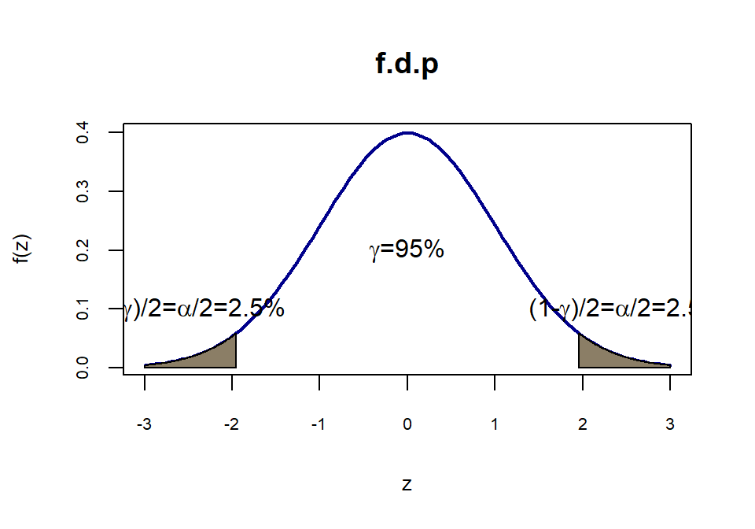

Intervalo de confiança para Normal com nível de confiança de 0.95

## Procedimento geral

- De uma maneira genérica podemos proceder da seguinte maneira:

$$\begin{array}{clc}
P(|Z_{\bar{X}}|<z_c)=\gamma
\\
\\
P(|\frac{\bar{X}-\mu}{\sigma_{\bar{X}}}|<z_c)=\gamma
\\
\\
P(|\bar{X}-\mu|<z_c\sigma_{\bar{X}})=\gamma
\\
\\
P(-z_c\sigma_{\bar{X}}<\bar{X}-\mu<z_c\sigma_{\bar{X}})=\gamma
\\
\\
P(\bar{X}-z_c\sigma_{\bar{X}} <\mu< \bar{X}+ z_c\sigma_{\bar{X}})=\gamma
\end{array}$$

## Procedimento Geral

- Assim, a probabilidade da esperança populacional $\mu$ estar entre o intervalo $\bar{X} \pm z_c\sigma_{\bar{X}}$ é igual $\gamma$.
- Sabendo que $\sigma_{\bar{X}}=\frac{\sigma}{\sqrt{n}}$, que dividiremos o nível de confiança nas duas caldas da distribuição, $z_{\frac{\alpha}{2}}$ podemos definir $L_n$ e $U_n$ para os diversos níveis de confiança como:

$$L_n=\bar{X}-z_{\frac{\alpha}{2}}\frac{\sigma}{\sqrt{n}} \quad \text{e} \quad U_n=\bar{X}+z_{\frac{\alpha}{2}}\frac{\sigma}{\sqrt{n}}$$

- A estimativa do intervalo de confiança para o parâmetro $\mu$ com nível de confiança de $\gamma$, ou $1-\alpha$:

$$IC(\mu;\gamma)=\bigg( \bar{x}-z_{\frac{\alpha}{2}}\frac{\sigma}{\sqrt{n}};\bar{x}+z_{\frac{\alpha}{2}}\frac{\sigma}{\sqrt{n}}\bigg)$$

## Procedimento para confiança 0.95

Para o exemplo com $\gamma=95$% e portanto, $\alpha=0.05$, tem-se que $z_{0.025}=1.96$ e o seguinte intervalo para 95% de confiança:

$$IC(\mu;0.95)=\bigg( \bar{x}-1.96\frac{\sigma}{\sqrt{n}};\bar{x}+1.96\frac{\sigma}{\sqrt{n}}\bigg)$$

- **A interpretação do intervalo de confiança**
  - Se fizessemos 100 intervalos de confiança, 95% deles conteriam o verdadeiro parâmetro populacional.
  - A propabilidade da esperança populacional estar no intervalo descrito acima é de 0.95
- A figura abaixo retirada de Bussab e Morettin, representa o que estamos fazendo:

## Graficamente

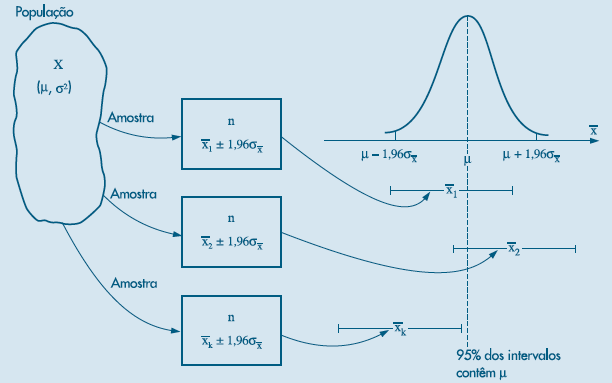

Intervalo de Confiança para a Esperança

## Simulando o intervalo de confiança

- Simulamos a estatística $f(\bar{X})$, uma amostragem aleatória de $X$, ou seja, $X_1,...,X_n$.
- Considerando Leis dos Grandes Números e Teorema do Limite Central sabemos que $\bar{X}\sim N(\mu,\frac{\sigma^2}{n})$.
- Especificamente sabemos aqui que $\bar{X}\sim N(50.000,1.000^2)$.
- Foram feitas 50 repetições do processo de amostragem.
- Calculamos para cada estimativa pontual um o intervalo de confiança, $U_n$ e $L_n$.
- Parte superior da figura é a distribuição da média $f(\bar{X})$ e a parte inferior os 50 intervalos de confiança.

## Simulando o intervalo de confiança

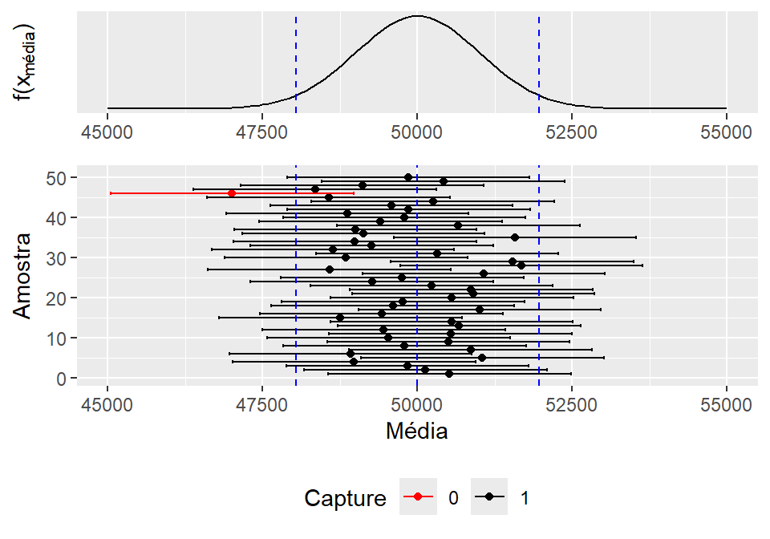

50 Intervalos de confiança de 0.95

## Simulando o intervalo de confiança

- Linhas em azul representam o intervalo do nível de confiança, ou seja, $\gamma=0.95$ para a distribuição da média.
- Barras em preto são intervalos que contêm a verdadeira média.
- Barras em vermelho os intervalos que não contêm a verdadeira média.
- Perceba que em poucos casos isso ocorre, apenas para os casos onde a estimativa pontual da média sai fora da linha azul.
- Isso acontece em apenas 5% das vezes, por construção, poisescolhemos o $z_c$ para o nível de confiança desejado.

## Simulando para diferentes níveis de confiança

- Para níveis de confiança menores, a linha azul anterior estará mais próximo a média.
- Portanto mais valores de intervalos não conterão o parâmetro populacional.
- Níveis de confiança menores produzirá intervalos de amplitudes menores.
- Com isso, encontraremos mais intervalos que não contêm o parâmetro populacional.
- Vejamos o gráfico abaixo:

## Simulando para diferentes níveis de confiança

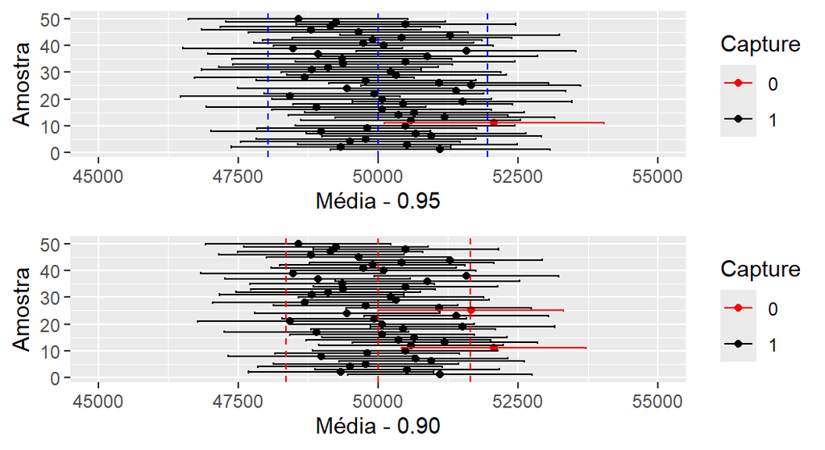

Comparando Intervalos de confiança de 0.90 e 0.95

## Exemplo

**EXEMPLO**

Temos uma máquina de empacotar café. Normalmente com $\mu=500$ e $\sigma^2=100$. A máquina desregulou e queremos saber qual a nova média $\mu$.

Temos uma amostra: $n=25$; $\overline{X}=485$

## Quando a variância é desconhecida

## Introdução

- Anteriomente tinhamos que:

$$Z_{\bar{X}}=\frac{\bar{X}-\mu}{\frac{\sigma}{\sqrt{n}}} \sim N(0,1)$$

- Não possuimos mais os valores de $\sigma$
- Alternativa trocar $\sigma$ pelo seu estimador $S_n$.
- Assim teriamos a segiunte formulação:

$$T_{\bar{X}}=\frac{\bar{X}-\mu}{\frac{S_n}{\sqrt{n}}}$$

## Definição

- Essa nova estatística terá a seguinte definição:

**DEFINIÇÃO**

Para uma amostra aleatória $X_1,...,X_n$ de uma variável aleatória $X \sim N(\mu, \sigma^2)$ desconhecidos, tem-se que:

$$T_{{\bar{X}}}=\frac{\bar{X}-\mu}{\frac{S_n}{\sqrt{n}}} \sim t(n-1)$$

tem distribuição t-student com $n-1$ graus de liberdade, $t(n-1)$, para qualquer valor de $\mu$ e $\sigma$.

## O intervalo de confiança com $\sigma$ desconhecida

- Dessa forma podemos definir o intervalo de confiança como:

$$P(\bar{X}-t_{n-1,\alpha/2}\frac{S_n}{\sqrt{n}} <\mu< \bar{X}+ t_{n-1,\alpha/2}\frac{S_n}{\sqrt{n}})=1-\alpha$$

- O intervalo de confiança para a esperança populacional será:

$$IC(\mu;\gamma)=\bigg( \bar{x}-t_{n-1,\alpha/2}\frac{S_n}{\sqrt{n}};\bar{x}+t_{n-1,\alpha/2}\frac{S_n}{\sqrt{n}}\bigg)$$

**OBS:** Para um amostra suficientemente grande podemos aproximar a distribuição t-student por uma normal padrão e calcular o intervalo de confiança com base na normal